# Travail pratique 2 - Analytique prédictive

Équipe 14: **MARTIN, SABRINA** (Matricule: 537381603) **KEITA, MAHOMET LIMENIA JEAN-YVES** (Matricule: 537175293) Date de remise: 2025-10-29

# 1. Forage de données : John Johnson chez Willmart

John Johnson est gestionnaire chez Willmart. Il cherche à mieux connaître les données sur l’article qui est meilleur vendeur dans leurs magasins afin de pouvoir prendre les bonnes décisions en tant que gestionnaire. Plus précisément, il cherche à savoir s’il y a un lien entre les ventes de cet item et la météo (température maximale et les précipitations).

CChargement des librairies nécessaires pour répondre à cette question: tidyverse {Wickham et al. (2019)} modelr {Wickham (2023)} lubridate {Grolemund and Wickham (2011)} stats {R Core Team (2025)} GGally {Schloerke et al. (2025)}

```r
library(tidyverse)
library(modelr)
library(lubridate)
library(stats)
library(GGally)
```

# 1.1 Lecture des données

Lecture des fichiers csv à partir d’un dossier zip à l’aide d’un chemin relatif. Les données proviennent de {Motl and Schulte (2015)}.

```r
willmart <- read_csv("./data/willmart.zip")
```

Indiquer s’il y a eu des problèmes lors de la lecture avec la fonction problems. Il n’y a pas eu de problèmes à la lecture du fichier.

```r
readr::problems(willmart)
```

```
## # A tibble: 0 × 5
## # ℹ 5 variables: row <int>, col <int>, expected <chr>, actual <chr>, file <chr>
```

Afficher les 3 premières lignes des données lues.

```r
willmart %>%
  head(3)
```

```
## # A tibble: 3 × 11
##    date storeId itemId units stationId  tmax  tmin  tavg snowfall preciptotal
##   <dbl>   <dbl>  <dbl> <dbl>     <dbl> <dbl> <dbl> <dbl>    <dbl>       <dbl>
## 1 15340       1      1     0         1    52    31    42       NA      0.0500
## 2 15340       1      2     0         1    52    31    42       NA      0.0500
## 3 15340       1      3     0         1    52    31    42       NA      0.0500
## # ℹ 1 more variable: avgspeed <dbl>
```

Afficher le nombre de d’observations lues dans le jeu de données.

```r
willmart %>%
  count()
```

```
## # A tibble: 1 × 1
##         n
##     <int>
## 1 4617600
```

# 1.2 Data cleaning et valeurs manquantes

John ne s’intéresse qu’aux magasins de la région qui sont liés à la station météo 3. Nous allons donc faire un filtre sur les données pour ne conserver que celles qui sont en lien avec la station météo 3. Le format de la date est aussi modifié pour pouvoir avoir une vraie date calendrier qui sera plus facile à manipuler plus tard. Le nombre d’observations a considérablement diminué pour notre analyse. Les données sont déjà rangées, chaque colonne correspond bien à une variable.

```r
willmart_clean_data <-
  willmart %>%
  filter(stationId == 3) %>%
  mutate(Date = as.Date(date), .before = date) %>%
  select(-stationId, -date)

#afficher données après le filter
willmart_clean_data %>%
  head(3)
```

```
## # A tibble: 3 × 10
##   Date       storeId itemId units  tmax  tmin  tavg snowfall preciptotal
##   <date>       <dbl>  <dbl> <dbl> <dbl> <dbl> <dbl>    <dbl>       <dbl>
## 1 2012-01-01      21      1     0    55    34    45        0           0
## 2 2012-01-01      21      2     0    55    34    45        0           0
## 3 2012-01-01      21      3     0    55    34    45        0           0
## # ℹ 1 more variable: avgspeed <dbl>
```

```r
#compter le nombre d'observations
willmart_clean_data %>%
  count()
```

```
## # A tibble: 1 × 1
##        n
##    <int>
## 1 304362
```

Vérifier le nombre de valeurs manquantes et dans quelles colonnes elles se situent. Osberver quelques lignes avec des valeurs manquantes.

```r
#compter le nombre de NA
willmart_clean_data %>% summarize(na_count = sum(is.na(.)))
```

```
## # A tibble: 1 × 1
##   na_count
##      <int>
## 1     5661
```

```r
#voir le nombre de NA par colonnes
willmart_clean_data %>%
  summarize(across(everything(), ~sum(is.na(.))))
```

```
## # A tibble: 1 × 10
##    Date storeId itemId units  tmax  tmin  tavg snowfall preciptotal avgspeed
##   <int>   <int>  <int> <int> <int> <int> <int>    <int>       <int>    <int>
## 1     0       0      0     0   666   666  1665     1332         666      666
```

```r
#voir les lignes avec des valeurs manquantes
valeur_manquante <- willmart_clean_data %>% filter(if_any(everything(), is.na))

valeur_manquante %>%
  head(3)
```

```
## # A tibble: 3 × 10
##   Date       storeId itemId units  tmax  tmin  tavg snowfall preciptotal
##   <date>       <dbl>  <dbl> <dbl> <dbl> <dbl> <dbl>    <dbl>       <dbl>
## 1 2012-07-31      21      1     0   112    88   100       NA           0
## 2 2012-07-31      21      2     0   112    88   100       NA           0
## 3 2012-07-31      21      3     0   112    88   100       NA           0
## # ℹ 1 more variable: avgspeed <dbl>
```

Pour la suite de l’analyse, nous aurons besoin des variables température maximale et prépicipations totale. Nous allons donc retirer les observations qui ont des valeurs manquantes de température maximale ou précipitations totales. Les valeurs manquantes restantes sont dans les colonnes température moyenne et quantité de neige, comme nous n’avons pas besoin de ces colonnes pour l’analyse elles seront retirées. Cela permet de retirer les valeurs manquantes du jeu de données sans retirer des observations. Suite à ces manipulations, il n’y a plus de valeurs manquantes.

```r
#filtrer pour retirer les observations qui ont valeurs manquantes tmax et preciptotal
#select pour retirer les colonnes snowfall et tavg qui ont aussi des valeurs manquantes
willmart_clean_data2 <-
willmart_clean_data %>%
  select(-snowfall, -tavg) %>%
  drop_na()

#affichage de la nouvelle table
willmart_clean_data2 %>%
  head(3)
```

```
## # A tibble: 3 × 8
##   Date       storeId itemId units  tmax  tmin preciptotal avgspeed
##   <date>       <dbl>  <dbl> <dbl> <dbl> <dbl>       <dbl>    <dbl>
## 1 2012-01-01      21      1     0    55    34           0       10
## 2 2012-01-01      21      2     0    55    34           0       10
## 3 2012-01-01      21      3     0    55    34           0       10
```

```r
#vérifier le nombre de valeurs manquantes et le nombre de lignes
willmart_clean_data2 %>%
  summarize(
    na_count = sum(is.na(.)), n = n())
```

```
## # A tibble: 1 × 2
##   na_count      n
##      <int>  <int>
## 1        0 303696
```

Faire les conversions en mesures métriques.

```r
willmart_data_converti <-
willmart_clean_data2 %>%
  mutate(preciptotal_mm = preciptotal * 25.4, .after = preciptotal) %>%
  mutate(avgspeed_kmh = avgspeed * 1.609344) %>%
  mutate(tmax_c = ((tmax - 32) * 5 / 9), .after = tmax) %>%
  mutate(tmin_c = ((tmin - 32) * 5 / 9), .after = tmin)

willmart_data_converti %>%
  head(3)
```

```
## # A tibble: 3 × 12
##   Date       storeId itemId units  tmax tmax_c  tmin tmin_c preciptotal
##   <date>       <dbl>  <dbl> <dbl> <dbl>  <dbl> <dbl>  <dbl>       <dbl>
## 1 2012-01-01      21      1     0    55   12.8    34   1.11           0
## 2 2012-01-01      21      2     0    55   12.8    34   1.11           0
## 3 2012-01-01      21      3     0    55   12.8    34   1.11           0
## # ℹ 3 more variables: preciptotal_mm <dbl>, avgspeed <dbl>, avgspeed_kmh <dbl>
```

# 1.3 Transformations et visualisations

John souhaite avoir quelques visualisations différentes pour trouver l’item qui se vend le plus.

Nous allons d’abord traiter les données en regroupant par numéro d’article et en faisant la somme des ventes pour tous les numéros d’articles. Ensuite, nous avons retiré les articles qui n’ont pas eu de ventes avec filtre. Un tri est effectué pour les mettre en ordre du plus gros nombre de ventes au plus petit. Ensuite, l’ajout d’une colonne pourcentage des ventes, et un filtre pour garder seulement les articles qui ont eu plus d’un pourcent des ventes totales. Cela nous permet de garder seulement les articles qui ont eu un nombre considérable de ventes pour les visualiser.

```r
sales_by_item <-
willmart_data_converti %>%
  group_by(itemId) %>%
  summarize(sales = sum(units)) %>%
  filter(sales >= 1) %>%
  arrange(desc(sales)) %>%
  mutate(percent = round(sales / sum(sales) * 100, 2)) %>%
  filter(percent >= 1)

sales_by_item
```

```
## # A tibble: 6 × 3
##   itemId  sales percent
##    <dbl>  <dbl>   <dbl>
## 1     44 258891   50.1
## 2      9 101412   19.6
## 3     45  58656   11.4
## 4      5  41510    8.04
## 5      8  30310    5.87
## 6     41  20555    3.98
```

Deux visualisations différentes permettent de constater que les ventes de l’article numéro 44 sont beaucoup plus élevées que les autres articles.

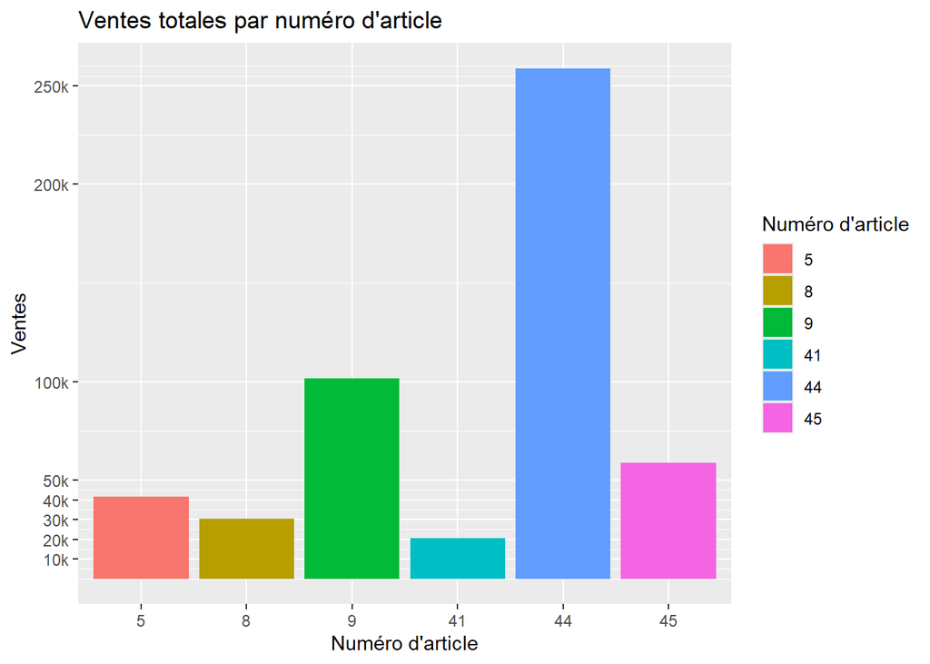

```r
sales_by_item %>%
  ggplot(aes(x = factor(itemId), y = sales, fill = factor(itemId))) +
  geom_bar(stat = "identity") +
  scale_y_continuous(
    breaks = c(10000, 20000, 30000, 40000, 50000, 100000, 200000, 250000),
    labels = c("10k", "20k", "30k", "40k", "50k", "100k", "200k", "250k")
  ) +
  labs(fill = "Numéro d'article",
       x = "Numéro d'article",
       y = "Ventes",
       title = "Ventes totales par numéro d'article")
```

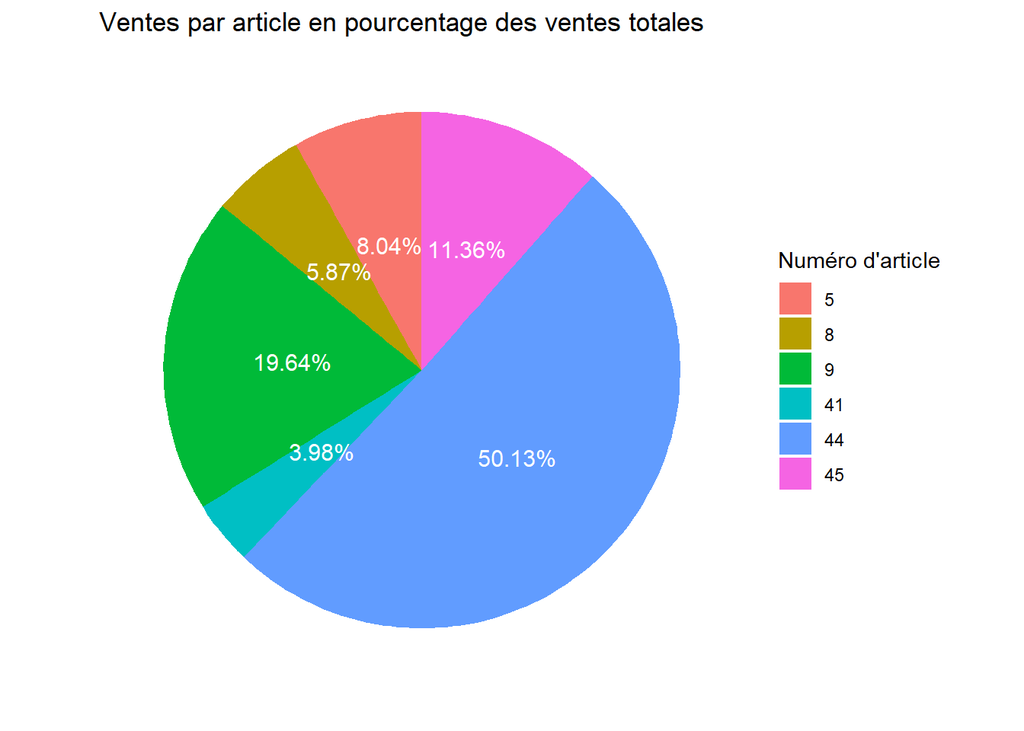

```r
sales_by_item %>%
  ggplot(aes(x = factor(1), y = percent, fill = factor(itemId))) +
  geom_bar(stat = "identity") +
  geom_text(aes(label = paste0(percent, "%")),
            position = position_stack(vjust = 0.5),
            color = "white",
            size = 4,
            check_overlap = TRUE) +
  coord_polar(theta = "y") +
  labs(x = " ", y = " ",
       fill = "Numéro d'article",
       title = "Ventes par article en pourcentage des ventes totales") +
  theme(axis.ticks = element_blank(),
        axis.text.x = element_blank(),
        axis.text.y = element_blank(),
        panel.background = element_blank()
        )
```

John souhaite avoir plus d’informations par rapport aux ventes de l’article 44. Nous appliquons un filtre pour garder seulement les observations de l’article 44. Un autre filtre permet de retirer les observations qui n’ont eu aucune vente de l’article 44. Ensuite, nous effectuons une vérification s’il y a des valeurs manquantes et le nombre de lignes suite au traitement.

```r
#plus besoin de la colonne itemID car nous gardons seulement les donnees pour l'article 44
#filtrer pour garder les ventes de plus de 1 unité de l'article 44
#retirer la colonne itemId car nous n'en avons plus besoin
donnees_article_44 <-
willmart_data_converti %>%
  filter(itemId == "44",
         units >= 1
         ) %>%
  select(-itemId)

donnees_article_44 %>%
  head()
```

```
## # A tibble: 6 × 11
##   Date       storeId units  tmax tmax_c  tmin tmin_c preciptotal preciptotal_mm
##   <date>       <dbl> <dbl> <dbl>  <dbl> <dbl>  <dbl>       <dbl>          <dbl>
## 1 2012-01-01      21   129    55  12.8     34  1.11            0              0
## 2 2012-01-02      21    60    45   7.22    24 -4.44            0              0
## 3 2012-01-03      21    72    55  12.8     21 -6.11            0              0
## 4 2012-01-04      21    46    63  17.2     31 -0.556           0              0
## 5 2012-01-05      21    84    68  20       31 -0.556           0              0
## 6 2012-01-06      21    65    69  20.6     40  4.44            0              0
## # ℹ 2 more variables: avgspeed <dbl>, avgspeed_kmh <dbl>
```

```r
donnees_article_44 %>%
  summarize(
    na_count = sum(is.na(.)), n = n())
```

```
## # A tibble: 1 × 2
##   na_count     n
##      <int> <int>
## 1        0  1822
```

John cherche des réponse à deux questions: 1. Quelles sont les ventes totales de l’article en fonction de la température maximale pour chacune des dates? 2. Quelles sont les ventes totales de l’item en fonction des précipitations totales pour chacune des dates?

Afin de pouvoir répondre à ces questions, nous allons d’abord traiter les données avant de les visualiser. Nous voulons savoir le nombre de ventes totales par date ainsi que la météo par date.

```r
#Pour les ventes de l'article 44, garder  seulement les observations qui ont plus d'une unité vendue
#faire le total des ventes par date et un tri sur la date
sales_44_by_date <-
donnees_article_44 %>%
  filter(units >= 1) %>%
  group_by(Date) %>%
  summarise(Ventes = sum(units)) %>%
  arrange(Date)

#voir les 3 premières lignes de cette table
sales_44_by_date %>%
  head(3)
```

```
## # A tibble: 3 × 2
##   Date       Ventes
##   <date>      <dbl>
## 1 2012-01-01    483
## 2 2012-01-02    110
## 3 2012-01-03    250
```

```r
#compter le nombre de lignes de cette table
sales_44_by_date %>%
  count()
```

```
## # A tibble: 1 × 1
##       n
##   <int>
## 1   911
```

```r
#trouver la météo par date
#supprimer les lignes en double
meteo_par_date <-
  donnees_article_44 %>%
  select(-storeId, -units) %>%
  arrange(Date) %>%
  distinct()

meteo_par_date %>%
  head(3)
```

```
## # A tibble: 3 × 9
##   Date        tmax tmax_c  tmin tmin_c preciptotal preciptotal_mm avgspeed
##   <date>     <dbl>  <dbl> <dbl>  <dbl>       <dbl>          <dbl>    <dbl>
## 1 2012-01-01    55  12.8     34   1.11           0              0    10
## 2 2012-01-02    45   7.22    24  -4.44           0              0     8.20
## 3 2012-01-03    55  12.8     21  -6.11           0              0    11.8
## # ℹ 1 more variable: avgspeed_kmh <dbl>
```

```r
meteo_par_date %>%
  count()
```

```
## # A tibble: 1 × 1
##       n
##   <int>
## 1   911
```

```r
#joindre les deux tables ensemble pour avoir le nombre total de ventes et les données de météo par date
#séparer la date en trois colonnes car nous aurons besoin plus tard de faire une visualisation par mois
ventes_meteo_par_date <-
  sales_44_by_date %>% left_join(meteo_par_date, by = "Date") %>%
  separate_wider_delim(Date, delim = "-", names = c("Année", "Mois", "Jour"), cols_remove = FALSE)

ventes_meteo_par_date %>%
  head()
```

```
## # A tibble: 6 × 13
##   Année Mois  Jour  Date       Ventes  tmax tmax_c  tmin tmin_c preciptotal
##   <chr> <chr> <chr> <date>      <dbl> <dbl>  <dbl> <dbl>  <dbl>       <dbl>
## 1 2012  01    01    2012-01-01    483    55  12.8     34  1.11            0
## 2 2012  01    02    2012-01-02    110    45   7.22    24 -4.44            0
## 3 2012  01    03    2012-01-03    250    55  12.8     21 -6.11            0
## 4 2012  01    04    2012-01-04    231    63  17.2     31 -0.556           0
## 5 2012  01    05    2012-01-05    441    68  20       31 -0.556           0
## 6 2012  01    06    2012-01-06    279    69  20.6     40  4.44            0
## # ℹ 3 more variables: preciptotal_mm <dbl>, avgspeed <dbl>, avgspeed_kmh <dbl>
```

```r
#vérifications valeurs manquantes et nombre de lignes suite à la jointure
ventes_meteo_par_date %>%
  summarize(
    na_count = sum(is.na(.)), n = n())
```

```
## # A tibble: 1 × 2
##   na_count     n
##      <int> <int>
## 1        0   911
```

### Quelles sont les ventes totales de l’article en fonction de la température maximale pour chacune des dates ?

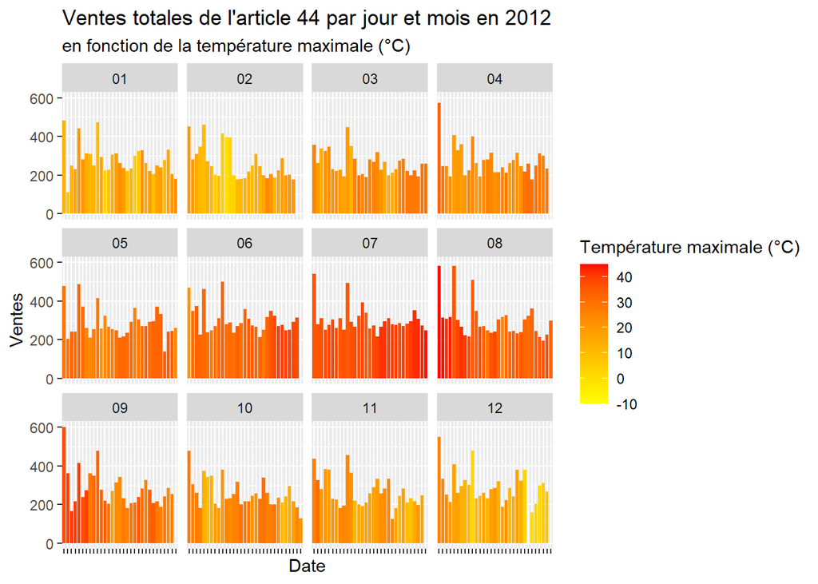

```r
graph_2012_temp <-
ventes_meteo_par_date %>%
  filter(Année == 2012) %>%
  ggplot(aes(x = factor(Jour), y = Ventes, fill = tmax_c)) +
  scale_fill_gradient(low = "yellow", high = "red", limits = c(-10, 45)) +
  geom_bar(stat = "identity") +
  facet_wrap(c("Mois")) +
  labs(x = "Date",
       y = "Ventes",
       title = "Ventes totales de l'article 44 par jour et mois en 2012",
       subtitle = "en fonction de la température maximale (°C)",
       fill = "Température maximale (°C)") +
  theme(axis.text.x = element_blank())

graph_2012_temp
```

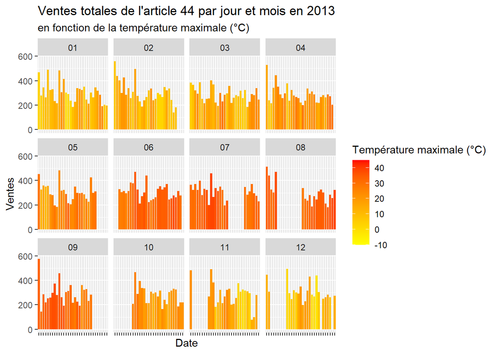

```r
graph_2013_temp <-
ventes_meteo_par_date %>%
  filter(Année == 2013) %>%
  ggplot(aes(x = factor(Jour), y = Ventes, fill = tmax_c)) +
  scale_fill_gradient(low = "yellow", high = "red", limits = c(-10, 45)) +
  geom_bar(stat = "identity") +
  facet_wrap(c("Mois")) +
  labs(x = "Date",
       y = "Ventes",
       title = "Ventes totales de l'article 44 par jour et mois en 2013",
       subtitle = "en fonction de la température maximale (°C)",
       fill = "Température maximale (°C)") +
  theme(axis.text.x = element_blank())

graph_2013_temp
```

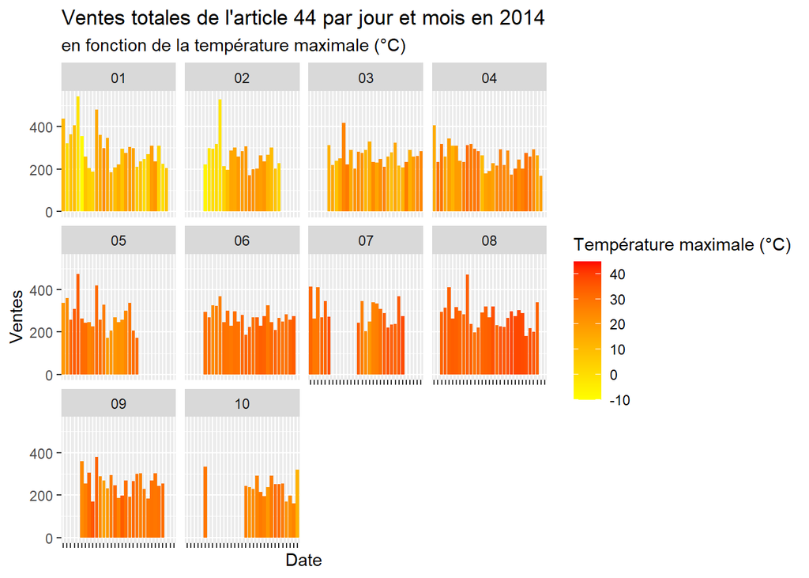

```r
graph_2014_temp <-
ventes_meteo_par_date %>%
  filter(Année == 2014) %>%
  ggplot(aes(x = factor(Jour), y = Ventes, fill = tmax_c)) +
  scale_fill_gradient(low = "yellow", high = "red", limits = c(-10, 45)) +
  geom_bar(stat = "identity") +
  facet_wrap(c("Mois")) +
  labs(x = "Date",
       y = "Ventes",
       title = "Ventes totales de l'article 44 par jour et mois en 2014",
       subtitle = "en fonction de la température maximale (°C)",
       fill = "Température maximale (°C)") +
  theme(axis.text.x = element_blank())

graph_2014_temp
```

### Quelles sont les ventes totales de l’item en fonction des précipitations totales pour chacune des dates?

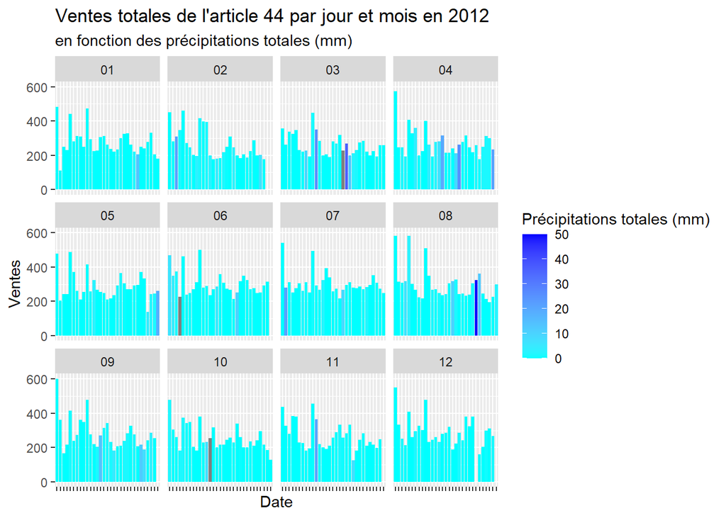

```r
graph_2012_precip <-
ventes_meteo_par_date %>%
  filter(Année == 2012) %>%
  ggplot(aes(x = factor(Jour), y = Ventes, fill = preciptotal_mm)) +
  scale_fill_gradient(low = "cyan", high = "blue", limits = c(0, 50)) +
  geom_bar(stat = "identity") +
  facet_wrap(c("Mois")) +
  labs(x = "Date",
       y = "Ventes",
       title = "Ventes totales de l'article 44 par jour et mois en 2012",
       subtitle = "en fonction des précipitations totales (mm)",
       fill = "Précipitations totales (mm)") +
  theme(axis.text.x = element_blank())

graph_2012_precip
```

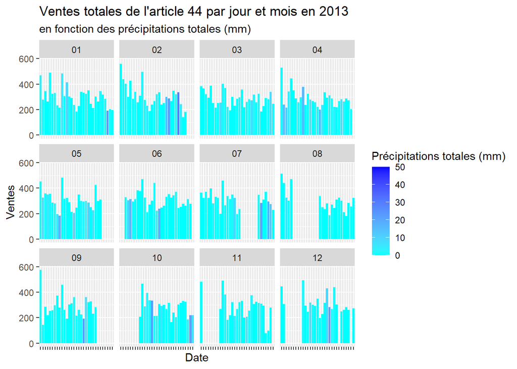

```r
graph_2013_precip <-
ventes_meteo_par_date %>%
  filter(Année == 2013) %>%
  ggplot(aes(x = factor(Jour), y = Ventes, fill = preciptotal_mm)) +
  scale_fill_gradient(low = "cyan", high = "blue", limits = c(0, 50)) +
  geom_bar(stat = "identity") +
  facet_wrap(c("Mois")) +
  labs(x = "Date",
       y = "Ventes",
       title = "Ventes totales de l'article 44 par jour et mois en 2013",
       subtitle = "en fonction des précipitations totales (mm)",
       fill = "Précipitations totales (mm)") +
  theme(axis.text.x = element_blank())

graph_2013_precip
```

[figure not shown]

```r
graph_2014_precip <-
ventes_meteo_par_date %>%
  filter(Année == 2014) %>%
  ggplot(aes(x = factor(Jour), y = Ventes, fill = preciptotal_mm)) +
  scale_fill_gradient(low = "cyan", high = "blue", limits = c(0, 50)) +
  geom_bar(stat = "identity") +
  facet_wrap(c("Mois")) +
  labs(x = "Date",
       y = "Ventes",
       title = "Ventes totales de l'article 44 par jour et mois en 2013",
       subtitle = "en fonction des précipitations totales (mm)",
       fill = "Précipitations totales (mm)") +
  theme(axis.text.x = element_blank())

graph_2014_precip
```

## Visualisations alternatives

Nous avons effectué des visualisations alternatives pour avoir plus d’informations.

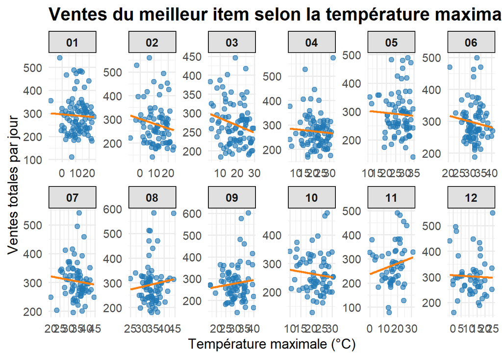

```r
ggplot(ventes_meteo_par_date, aes(x = tmax_c, y = Ventes)) +
  geom_point(alpha = 0.6, size = 2, color = "#1f77b4") +
  geom_smooth(method = "lm", se = FALSE, linewidth = 1, color = "#ff7f0e") +
  facet_wrap(~ Mois, scales = "free", nrow = 2) +
  labs(title = paste("Ventes du meilleur item","selon la température maximale"),
       x = "Température maximale (°C)",
       y = "Ventes totales par jour") +
  theme_minimal(base_size = 14) +
  theme(
    plot.title = element_text(face = "bold", size = 18),
    strip.background = element_rect(fill = "#e0e0e0"),
    strip.text = element_text(face = "bold")
  )
```

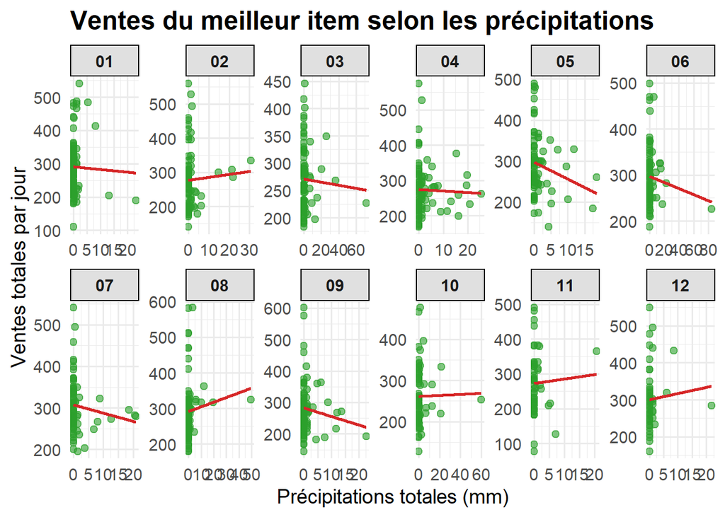

```r
# Visualisation : Ventes vs Précipitations (preciptotal)

ggplot(ventes_meteo_par_date, aes(x = preciptotal_mm, y = Ventes)) +
  geom_point(alpha = 0.6, size = 2, color = "#2ca02c") +
  geom_smooth(method = "lm", se = FALSE, linewidth = 1, color = "#d62728") +
  facet_wrap(~ Mois, scales = "free", nrow = 2) +
  labs(title = paste("Ventes du meilleur item", "selon les précipitations"),
       x = "Précipitations totales (mm)",
       y = "Ventes totales par jour") +
  theme_minimal(base_size = 14) +
  theme(
    plot.title = element_text(face = "bold", size = 18),
    strip.background = element_rect(fill = "#e0e0e0"),
    strip.text = element_text(face = "bold")
  )
```